# Forest Fires

Alice Giampino

2023-12-01

## Forest fire

Questo dataset è pubblico e a disposizione per la ricerca. I dettagli sul dataset possono essere trovati in Cortez e Morais (2007). Il dataset è composto dalle seguenti variabili:

1. Coordinata spaziale dell’asse X all’interno della mappa del parco Montesinho: da 1 a 9
2. Y coordinata spaziale dell’asse y all’interno della mappa del parco Montesinho: da 2 a 9
3. mese: mese dell’anno: da “gen” a “dic”
4. giorno della settimana: da “lunedì” a “domenica”
5. Indice FFMC dal sistema FWI: da 18,7 a 96,20
6. Indice DMC dal sistema FWI: da 1,1 a 291,3
7. Indice DC dal sistema FWI: da 7,9 a 860,6
8. Indice ISI del sistema FWI: da 0,0 a 56,10
9. temperatura temporanea in gradi Celsius: da 2,2 a 33,30
10. Umidità relativa RH in %: da 15,0 a 100
11. velocità del vento in km/h: da 0,40 a 9,40
12. pioggia in mm/m2: da 0,0 a 6,4
13. area della superficie bruciata della foresta (in ettari): da 0,00 a 1090,84.

In questo dataset siamo interessati a modellare l’area bruciata della foresta come funzione delle altre variabili.

Cortez P. e Morais A. “Un approccio di data mining per prevedere gli incendi boschivi utilizzando dati meteorologici.” In J. Neves, MF Santos e J. Machado Eds., “Nuove tendenze nell’intelligenza artificiale”, Atti della 13a EPIA 2007 Conferenza portoghese sull’intelligenza artificiale, dicembre, Guimaraes, Por- tugal, pp. 512-523, 2007. APPIA, ISBN-13 978-989-95618-0-9. 18-0-9. Disponibile a: http://www3.dsi.uminho.pt/pcortez/fires.pdf

Punti 1-4 di come scrivere un buon report:

```
##  [1] "X"     "Y"     "month" "day"   "FFMC"  "DMC"   "DC"    "ISI"   "temp"
## [10] "RH"    "wind"  "rain"  "area"
```

```
##        X               Y          month               day
##  Min.   :1.000   Min.   :2.0   Length:517         Length:517
##  1st Qu.:3.000   1st Qu.:4.0   Class :character   Class :character
##  Median :4.000   Median :4.0   Mode  :character   Mode  :character
##  Mean   :4.669   Mean   :4.3
##  3rd Qu.:7.000   3rd Qu.:5.0
##  Max.   :9.000   Max.   :9.0
##       FFMC            DMC              DC             ISI
##  Min.   :18.70   Min.   :  1.1   Min.   :  7.9   Min.   : 0.000
##  1st Qu.:90.20   1st Qu.: 68.6   1st Qu.:437.7   1st Qu.: 6.500
##  Median :91.60   Median :108.3   Median :664.2   Median : 8.400
##  Mean   :90.64   Mean   :110.9   Mean   :547.9   Mean   : 9.022
##  3rd Qu.:92.90   3rd Qu.:142.4   3rd Qu.:713.9   3rd Qu.:10.800
##  Max.   :96.20   Max.   :291.3   Max.   :860.6   Max.   :56.100
##       temp             RH              wind            rain
##  Min.   : 2.20   Min.   : 15.00   Min.   :0.400   Min.   :0.00000
##  1st Qu.:15.50   1st Qu.: 33.00   1st Qu.:2.700   1st Qu.:0.00000
##  Median :19.30   Median : 42.00   Median :4.000   Median :0.00000
##  Mean   :18.89   Mean   : 44.29   Mean   :4.018   Mean   :0.02166
##  3rd Qu.:22.80   3rd Qu.: 53.00   3rd Qu.:4.900   3rd Qu.:0.00000
##  Max.   :33.30   Max.   :100.00   Max.   :9.400   Max.   :6.40000
##       area
##  Min.   :   0.00
##  1st Qu.:   0.00
##  Median :   0.52
##  Mean   :  12.85
##  3rd Qu.:   6.57
##  Max.   :1090.84
```

```
## [1] 0
```

```
##   month day FFMC  DMC    DC  ISI temp RH wind rain area
## 1   mar fri 86.2 26.2  94.3  5.1  8.2 51  6.7  0.0    0
## 2   oct tue 90.6 35.4 669.1  6.7 18.0 33  0.9  0.0    0
## 3   oct sat 90.6 43.7 686.9  6.7 14.6 33  1.3  0.0    0
## 4   mar fri 91.7 33.3  77.5  9.0  8.3 97  4.0  0.2    0
## 5   mar sun 89.3 51.3 102.2  9.6 11.4 99  1.8  0.0    0
## 6   aug sun 92.3 85.3 488.0 14.7 22.2 29  5.4  0.0    0
```

```
##      month      day          FFMC            DMC              DC
##  aug    :184   fri:85   Min.   :18.70   Min.   :  1.1   Min.   :  7.9
##  sep    :172   mon:74   1st Qu.:90.20   1st Qu.: 68.6   1st Qu.:437.7
##  mar    : 54   sat:84   Median :91.60   Median :108.3   Median :664.2
##  jul    : 32   sun:95   Mean   :90.64   Mean   :110.9   Mean   :547.9
##  feb    : 20   thu:61   3rd Qu.:92.90   3rd Qu.:142.4   3rd Qu.:713.9
##  jun    : 17   tue:64   Max.   :96.20   Max.   :291.3   Max.   :860.6
##  (Other): 38   wed:54
##       ISI              temp             RH              wind
##  Min.   : 0.000   Min.   : 2.20   Min.   : 15.00   Min.   :0.400
##  1st Qu.: 6.500   1st Qu.:15.50   1st Qu.: 33.00   1st Qu.:2.700
##  Median : 8.400   Median :19.30   Median : 42.00   Median :4.000
##  Mean   : 9.022   Mean   :18.89   Mean   : 44.29   Mean   :4.018
##  3rd Qu.:10.800   3rd Qu.:22.80   3rd Qu.: 53.00   3rd Qu.:4.900
##  Max.   :56.100   Max.   :33.30   Max.   :100.00   Max.   :9.400
##
##       rain              area
##  Min.   :0.00000   Min.   :   0.00
##  1st Qu.:0.00000   1st Qu.:   0.00
##  Median :0.00000   Median :   0.52
##  Mean   :0.02166   Mean   :  12.85
##  3rd Qu.:0.00000   3rd Qu.:   6.57
##  Max.   :6.40000   Max.   :1090.84
##
```

```
##
## apr aug dec feb jan jul jun mar may nov oct sep
##   9 184   9  20   2  32  17  54   2   1  15 172
```

```
##
## fri mon sat sun thu tue wed
##  85  74  84  95  61  64  54
```

```
##
##       fri mon sat sun thu tue wed
##   apr   1   1   1   3   2   0   1
##   aug  21  15  29  40  26  28  25
##   dec   1   4   0   1   1   1   1
##   feb   5   3   4   4   1   2   1
##   jan   0   0   1   1   0   0   0
##   jul   3   4   8   5   3   6   3
##   jun   3   3   2   4   2   0   3
##   mar  11  12  10   7   5   5   4
##   may   1   0   1   0   0   0   0
##   nov   0   0   0   0   0   1   0
##   oct   1   4   3   3   0   2   2
##   sep  38  28  25  27  21  19  14
```

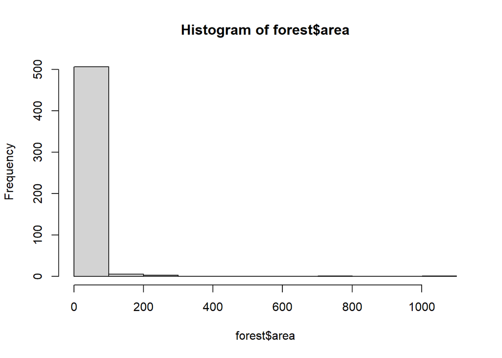

```
##    Min. 1st Qu.  Median    Mean 3rd Qu.    Max.
##    0.00    0.00    0.52   12.85    6.57 1090.84
```

```
## [1] 0.4777563
```

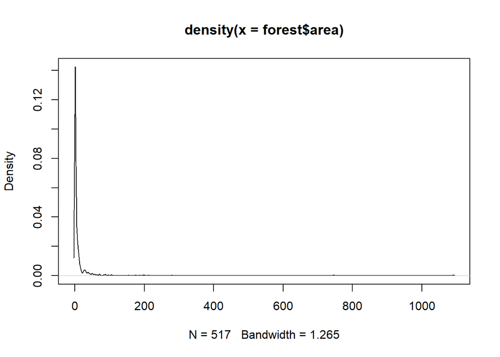

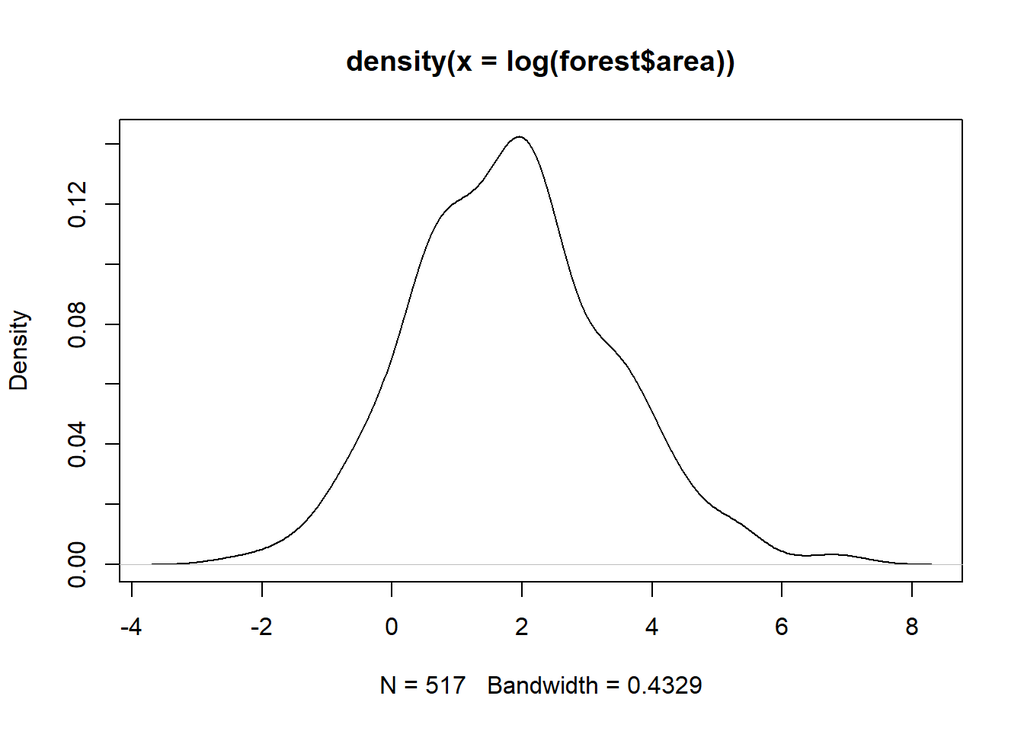

```
##    Min. 1st Qu.  Median    Mean 3rd Qu.    Max.
##  0.0000  0.0000  0.4187  1.1110  2.0242  6.9956
```

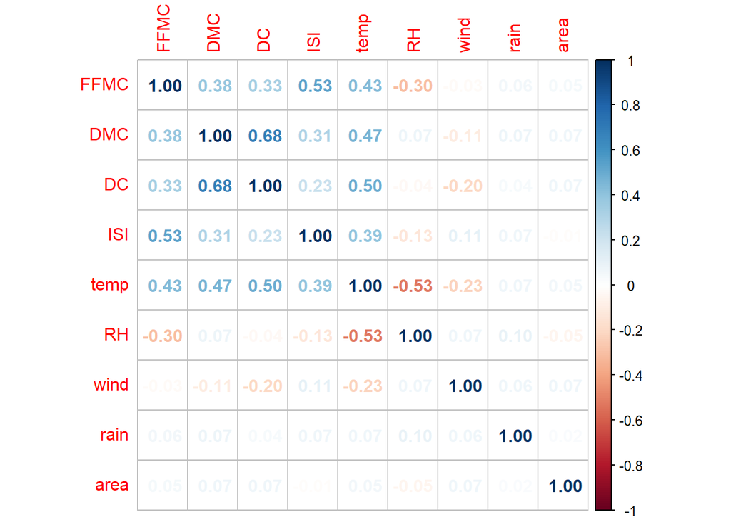

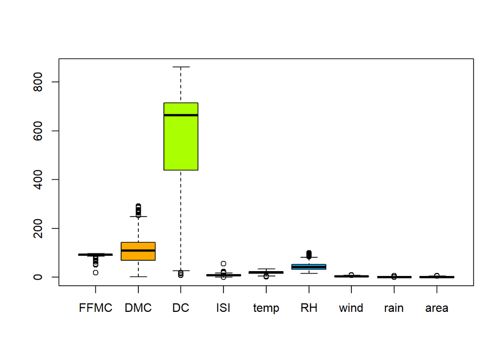

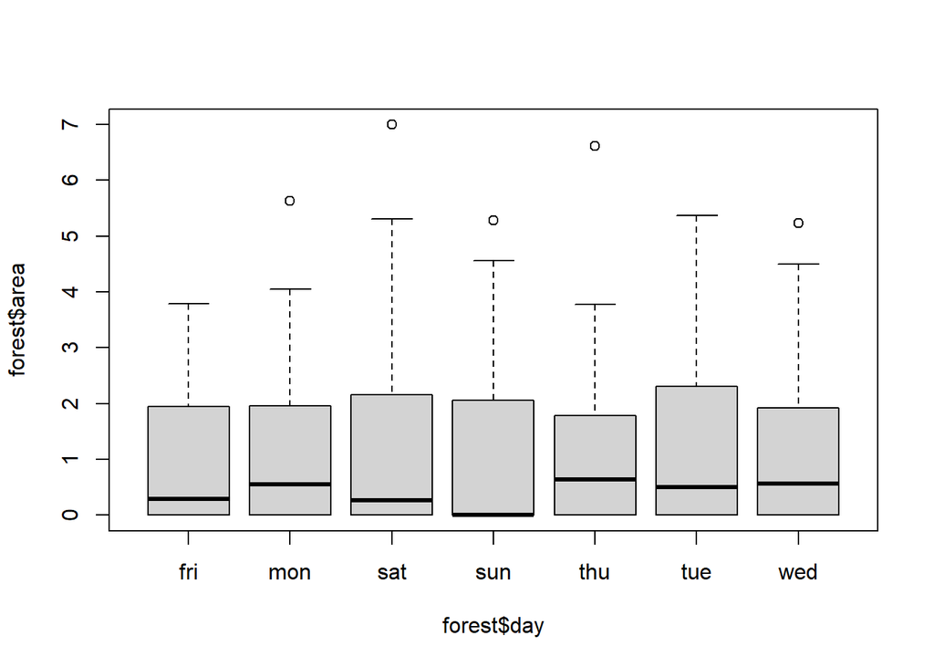

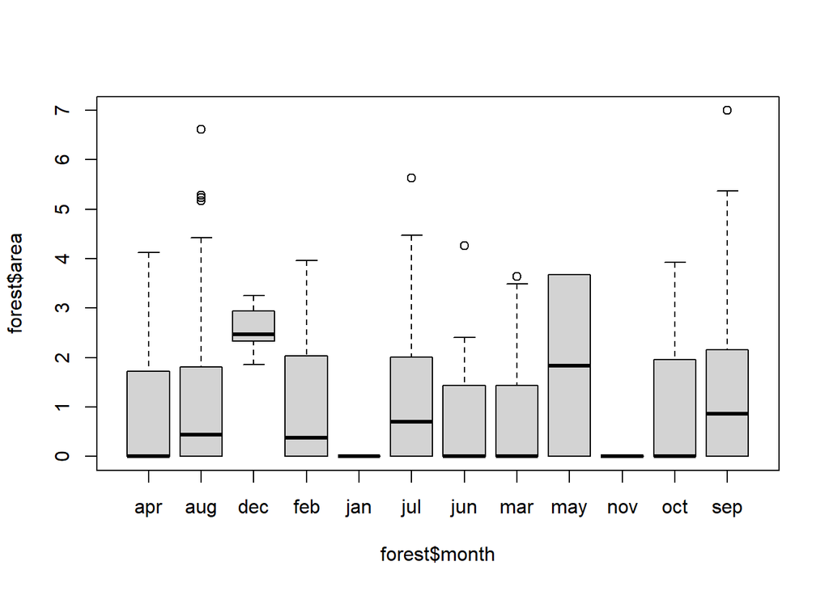

Potete prendere spunto da questo notebook: https://rstudio-pubs-static.s3.amazonaws.com/419751_b251adb1ab8e40f7aeab8b5c4a739c4f.html

Punti 5-6 di come scrivere un buon report:

```r
# si divide il dataset in train e test (validation) così che si fitta il modello sul train e si guarda la capacità predittiva su nuovi dati, questo serve per evitare di over-fittare i dati di train e fare un modello che si adatta solo ai dati visti dal modello:

# Optional:
forest <- fastDummies::dummy_cols(forest, remove_first_dummy = TRUE)[-c(1,2)]

# Regole classiche sono 70% training e 30% test (o 80-20 a vostra scelta)
set.seed(125) # il seme serve per riprodurre le analisi (reproducibilità del codice)
sample <- sample(c(TRUE, FALSE), nrow(forest), replace=TRUE, prob=c(0.7,0.3))
train  <- forest[sample, ]
test   <- forest[!sample, ]

# Modello con una sola variabile:
model = lm(area ~ rain, data = train)

summary(model)
```

```
##
## Call:
## lm(formula = area ~ rain, data = train)
##
## Residuals:
##     Min      1Q  Median      3Q     Max
## -1.1169 -1.1169 -0.6982  0.9086  5.8787
##
## Coefficients:
##             Estimate Std. Error t value Pr(>|t|)
## (Intercept)  1.11694    0.07539   14.82   <2e-16 ***
## rain        -1.41984    0.92201   -1.54    0.124
## ---
## Signif. codes:  0 '***' 0.001 '**' 0.01 '*' 0.05 '.' 0.1 ' ' 1
##
## Residual standard error: 1.409 on 351 degrees of freedom
## Multiple R-squared:  0.006711,   Adjusted R-squared:  0.003881
## F-statistic: 2.371 on 1 and 351 DF,  p-value: 0.1245
```

```r
# Modello con tutte le variabili:
model1 = lm(area ~ ., data = train)
summary(model1)
```

```
##
## Call:
## lm(formula = area ~ ., data = train)
##
## Residuals:
##     Min      1Q  Median      3Q     Max
## -2.0509 -0.9930 -0.4196  0.9067  5.0839
##
## Coefficients: (1 not defined because of singularities)
##              Estimate Std. Error t value Pr(>|t|)
## (Intercept) -1.104088   2.062474  -0.535   0.5928
## FFMC         0.007967   0.021031   0.379   0.7051
## DMC          0.003311   0.002244   1.476   0.1410
## DC          -0.002105   0.001694  -1.242   0.2150
## ISI          0.001891   0.020749   0.091   0.9275
## temp         0.044480   0.026364   1.687   0.0925 .
## RH           0.005247   0.007595   0.691   0.4901
## wind         0.102497   0.045852   2.235   0.0261 *
## rain        -1.781002   0.955096  -1.865   0.0631 .
## month_aug    0.248307   1.070361   0.232   0.8167
## month_dec    2.213667   0.994994   2.225   0.0268 *
## month_feb    0.408489   0.650106   0.628   0.5302
## month_jan   -0.541694   1.307862  -0.414   0.6790
## month_jul   -0.037427   0.896186  -0.042   0.9667
## month_jun   -0.696132   0.824498  -0.844   0.3991
## month_mar   -0.379072   0.576235  -0.658   0.5111
## month_may    2.705751   1.487261   1.819   0.0698 .
## month_nov          NA         NA      NA       NA
## month_oct    1.211886   1.261942   0.960   0.3376
## month_sep    1.021802   1.208243   0.846   0.3983
## day_mon      0.207708   0.274390   0.757   0.4496
## day_sat      0.616573   0.269198   2.290   0.0226 *
## day_sun      0.419913   0.263989   1.591   0.1127
## day_thu      0.473808   0.300514   1.577   0.1158
## day_tue      0.506912   0.296819   1.708   0.0886 .
## day_wed      0.121176   0.297501   0.407   0.6840
## ---
## Signif. codes:  0 '***' 0.001 '**' 0.01 '*' 0.05 '.' 0.1 ' ' 1
##
## Residual standard error: 1.376 on 328 degrees of freedom
## Multiple R-squared:  0.1151, Adjusted R-squared:  0.05033
## F-statistic: 1.777 on 24 and 328 DF,  p-value: 0.01496
```

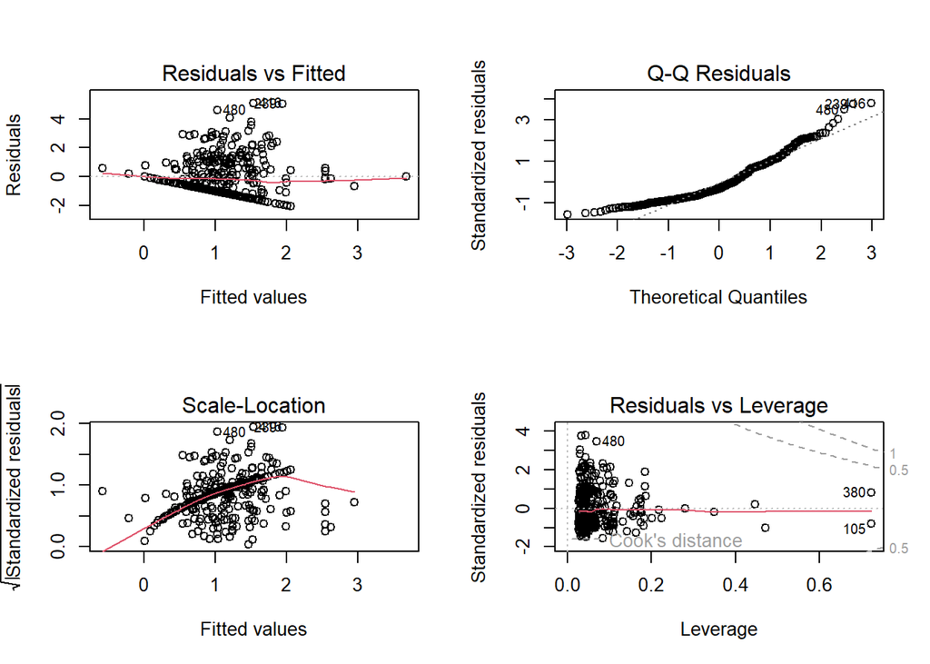

```r
# Diagnostic plot del modello:
par(mfrow=c(2,2)) # finestra grafica 2x2
plot(model1)
```

```r
par(mfrow=c(1,1)) # riportiamo ai valori di default

# rimuovere outlier:
# install.packages("olsrr")
library(olsrr)
```

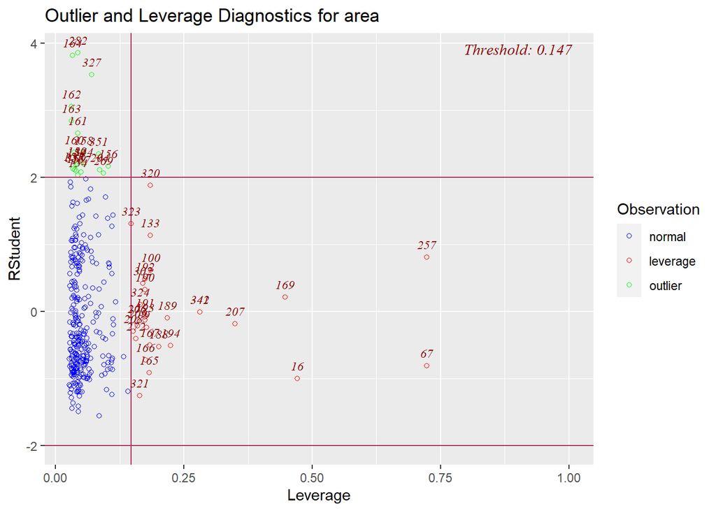

```r
ols_plot_resid_lev(model1)
```

```r
# Removing observations guardando numero dell'osservazione:
train = train[-c(205, 57, 257, 380),]

# Rimuovere osservazioni basandoci sui valori delle variabili:
# train=train[!(train$temp>300),]

# Modello 1 senza outlier:
model2 = lm(area ~ ., data = train)
summary(model2)
```

```
##
## Call:
## lm(formula = area ~ ., data = train)
##
## Residuals:
##     Min      1Q  Median      3Q     Max
## -2.0598 -0.9761 -0.3869  0.8925  5.0381
##
## Coefficients: (1 not defined because of singularities)
##              Estimate Std. Error t value Pr(>|t|)
## (Intercept) -2.192948   2.573014  -0.852   0.3947
## FFMC         0.020658   0.027752   0.744   0.4572
## DMC          0.003377   0.002252   1.500   0.1346
## DC          -0.002352   0.001704  -1.380   0.1685
## ISI         -0.003254   0.022026  -0.148   0.8827
## temp         0.045366   0.026453   1.715   0.0873 .
## RH           0.005580   0.007653   0.729   0.4665
## wind         0.103915   0.046070   2.256   0.0248 *
## rain        -1.771393   0.957271  -1.850   0.0652 .
## month_aug    0.333227   1.072461   0.311   0.7562
## month_dec    2.306296   0.997807   2.311   0.0214 *
## month_feb    0.459651   0.651874   0.705   0.4812
## month_jan   -1.110503   1.498045  -0.741   0.4590
## month_jul   -0.044321   0.898293  -0.049   0.9607
## month_jun   -0.629005   0.829120  -0.759   0.4486
## month_mar   -0.408918   0.578868  -0.706   0.4804
## month_may    2.668467   1.488878   1.792   0.0740 .
## month_nov          NA         NA      NA       NA
## month_oct    1.327741   1.264737   1.050   0.2946
## month_sep    1.142335   1.211402   0.943   0.3464
## day_mon      0.204167   0.274637   0.743   0.4578
## day_sat      0.628463   0.269823   2.329   0.0205 *
## day_sun      0.408165   0.264637   1.542   0.1240
## day_thu      0.509569   0.303015   1.682   0.0936 .
## day_tue      0.478056   0.298930   1.599   0.1107
## day_wed      0.114097   0.297734   0.383   0.7018
## ---
## Signif. codes:  0 '***' 0.001 '**' 0.01 '*' 0.05 '.' 0.1 ' ' 1
##
## Residual standard error: 1.376 on 325 degrees of freedom
## Multiple R-squared:  0.1182, Adjusted R-squared:  0.05307
## F-statistic: 1.815 on 24 and 325 DF,  p-value: 0.01214
```

```r
# Modello con variabili scelte da noi (scelte casualmente al momento):
model3 = lm(area ~ month_dec+wind+rain+temp+I(FFMC*month_aug), data = train)
summary(model3)
```

```
##
## Call:
## lm(formula = area ~ month_dec + wind + rain + temp + I(FFMC *
##     month_aug), data = train)
##
## Residuals:
##     Min      1Q  Median      3Q     Max
## -1.6347 -1.0595 -0.6214  0.8942  5.6025
##
## Coefficients:
##                      Estimate Std. Error t value Pr(>|t|)
## (Intercept)          0.239186   0.339282   0.705   0.4813
## month_dec            1.543049   0.625734   2.466   0.0142 *
## wind                 0.080864   0.043400   1.863   0.0633 .
## rain                -1.479449   0.921812  -1.605   0.1094
## temp                 0.033088   0.014519   2.279   0.0233 *
## I(FFMC * month_aug) -0.002723   0.001831  -1.487   0.1379
## ---
## Signif. codes:  0 '***' 0.001 '**' 0.01 '*' 0.05 '.' 0.1 ' ' 1
##
## Residual standard error: 1.39 on 344 degrees of freedom
## Multiple R-squared:  0.04833,    Adjusted R-squared:  0.03449
## F-statistic: 3.494 on 5 and 344 DF,  p-value: 0.00429
```

```r
# Test ANOVA
anova(model3)
```

```
## Analysis of Variance Table
##
## Response: area
##                      Df Sum Sq Mean Sq F value   Pr(>F)
## month_dec             1  13.93 13.9255  7.2115 0.007595 **
## wind                  1   3.31  3.3119  1.7151 0.191198
## rain                  1   5.56  5.5559  2.8772 0.090749 .
## temp                  1   6.67  6.6674  3.4528 0.063999 .
## I(FFMC * month_aug)   1   4.27  4.2712  2.2119 0.137868
## Residuals           344 664.27  1.9310
## ---
## Signif. codes:  0 '***' 0.001 '**' 0.01 '*' 0.05 '.' 0.1 ' ' 1
```

### Confronto tra modelli:

```r
# Create vector with values
a = c(AIC(model3), BIC(model3), AIC(model2), BIC(model2), AIC(model1), BIC(model1))

# Akaike Information Criterion (AIC) estimates the in-sample prediction error and indicates the relative quality of statistical models for a given dataset (it is only useful to compare models based on the same data). Bayesian Information Criterion (BIC) is a penalized-likelihood criterion derived from Bayesian probability. It is closely related to AIC. Generally, lower values of BIC and AIC are preferred.

# Create vector with nforest
b = c("AIC lm 3", "BIC lm 3", "AIC lm 2", "BIC lm 2", "AIC lm 1", "BIC lm 1")

# Link the values with nforest
names(a) = b
print(a)
```

```
## AIC lm 3 BIC lm 3 AIC lm 2 BIC lm 2 AIC lm 1 BIC lm 1
## 1231.521 1258.527 1242.837 1343.143 1252.933 1353.461
```

```r
#use lasso regression model to predict response value
new = test
previsioni_mod3 = predict(model3, newdata = new)

#find SST and SSE
sst <- sum((test$area - mean(test$area))^2)
sse <- sum((previsioni_mod3 - test$area)^2)

# Root Mean Squared Error: è una misura dell'errore che compiamo
sqrt(mean((test$area - previsioni_mod3)^2))
```

```
## [1] 1.595067
```

```r
# intervallo di previsione
predict(model3,new,interval="predict", level=0.95)
```

```
##            fit         lwr      upr
## 1    1.0522935  -1.7064859 3.811073
## 5    0.7619410  -1.9905051 3.514387
## 6    1.1590728  -1.5880883 3.906234
## 12   1.2012343  -1.5387640 3.941233
## 18   1.1879839  -1.5527587 3.928726
## 20   0.9107894  -1.8382256 3.659804
## 22   1.0894937  -1.6519754 3.830963
## 27   1.3368631  -1.4081783 4.081904
## 31   1.3707237  -1.3779486 4.119396
## 33   1.0663477  -1.6794783 3.812174
## 35   1.1589779  -1.5838377 3.901793
## 39   1.1516028  -1.5878692 3.891075
## 41   1.2608076  -1.4839401 4.005555
## 43   0.9669744  -1.7836785 3.717627
```

[output cut: 150 more lines]

### LASSO regression:

```r
# install.packages("glmnet") # se non è già stato installato
library(glmnet)
#define response variable
y <- train$area

#define matrix of predictor variables (uso solo poche variabili ma potete farlo con tutte da togliere però la risposta area)
x <- data.matrix(train[, c("month_dec","wind","rain","temp","FFMC","month_aug")])

#perform k-fold cross-validation to find optimal lambda value, la cross-validation è un ottimo modo per non overfittare e trovare il miglior modello
cv_model <- cv.glmnet(x, y, alpha = 1)

#find optimal lambda value that minimizes test MSE
best_lambda <- cv_model$lambda.min
best_lambda
```

```
## [1] 0.0007509814
```

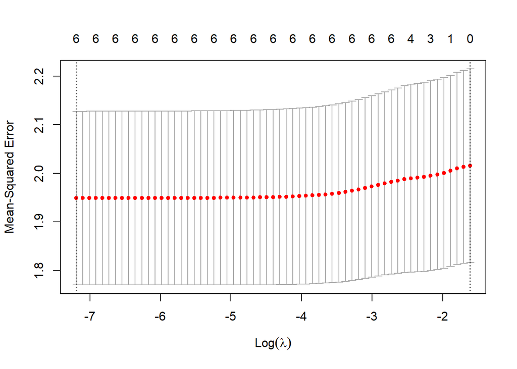

```r
#produce plot of test MSE by lambda value
plot(cv_model)
```

```r
# Fittiamo il modello con il best lambda (penalizzazione)

best_model <- glmnet(x, y, alpha = 1, lambda = best_lambda)
coef(best_model)
```

```
## 7 x 1 sparse Matrix of class "dgCMatrix"
##                      s0
## (Intercept) -0.97341165
## month_dec    1.55120590
## wind         0.07990861
## rain        -1.51410685
## temp         0.02798380
## FFMC         0.01448126
## month_aug   -0.26416341
```

### Previsioni con Lasso:

```r
#use lasso regression model to predict response value
new = data.matrix(test[,c("month_dec","wind","rain","temp","FFMC","month_aug")])
previsioni = predict(best_model, s = best_lambda, newx = new)

# Root Mean Squared Error (RMSE): è una misura dell'errore che compiamo
sqrt(mean((test$area - previsioni)^2))
```

```
## [1] 1.604813
```

Ora potete confrontare modelli diversi con lasso e lm classici, vedete cosa vi dice BIC/AIC e RMSE per decidere quale è il modello ottimale.

## Modello con soglia scelta: logit - glm

```r
forest$area2 <- as.factor(ifelse(forest$area>0.5,1,0))

# Regole classiche sono 70% training e 30% test (o 80-20 a vostra scelta)
set.seed(125) # il seme serve per riprodurre le analisi (reproducibilità del codice)
sample <- sample(c(TRUE, FALSE), nrow(forest), replace=TRUE, prob=c(0.7,0.3))
train  <- forest[sample, ]
test   <- forest[!sample, ]

# Modello con una sola variabile:
model = glm(area2 ~ rain, data = train, family = binomial(link="logit"))
# o va bene anche: family="binomial"
summary(model)
```

```
##
## Call:
## glm(formula = area2 ~ rain, family = binomial(link = "logit"),
##     data = train)
##
## Coefficients:
##               Estimate Std. Error z value Pr(>|z|)
## (Intercept)   -0.04599    0.10724  -0.429    0.668
## rain         -73.92369 3562.53148  -0.021    0.983
##
## (Dispersion parameter for binomial family taken to be 1)
##
##     Null deviance: 488.88  on 352  degrees of freedom
## Residual deviance: 482.25  on 351  degrees of freedom
## AIC: 486.25
##
## Number of Fisher Scoring iterations: 16
```

```r
# Modello con tutte le variabili:
model1 = glm(area2 ~ ., data = train, family = binomial(link="logit"))
summary(model1)
```

```
##
## Call:
## glm(formula = area2 ~ ., family = binomial(link = "logit"), data = train)
##
## Coefficients: (1 not defined because of singularities)
##               Estimate Std. Error z value Pr(>|z|)
## (Intercept) -7.179e+02  7.479e+05  -0.001    0.999
## FFMC         2.824e+00  6.219e+03   0.000    1.000
## DMC         -4.230e-01  1.343e+03   0.000    1.000
## DC           3.245e-01  3.106e+02   0.001    0.999
## ISI          7.254e-02  1.145e+04   0.000    1.000
## temp         6.947e+00  4.898e+03   0.001    0.999
## RH           1.534e+00  1.572e+03   0.001    0.999
## wind         6.871e+00  3.230e+03   0.002    0.998
## rain         3.588e+00  1.989e+05   0.000    1.000
## area         1.784e+02  2.636e+04   0.007    0.995
## month_aug   -5.657e+01  4.200e+05   0.000    1.000
## month_dec   -1.850e+02  4.481e+05   0.000    1.000
## month_feb    1.989e+02  4.335e+05   0.000    1.000
## month_jan    2.193e+02  4.645e+05   0.000    1.000
## month_jul   -4.400e+00  4.197e+05   0.000    1.000
## month_jun    3.193e+01  4.392e+05   0.000    1.000
## month_mar    1.769e+02  4.480e+05   0.000    1.000
## month_may   -3.916e+02  5.518e+05  -0.001    0.999
## month_nov           NA         NA      NA       NA
## month_oct   -2.743e+02  6.258e+05   0.000    1.000
## month_sep   -6.737e+01  4.248e+05   0.000    1.000
## day_mon      3.591e+01  4.249e+04   0.001    0.999
## day_sat      6.189e+01  3.421e+04   0.002    0.999
## day_sun      1.663e+01  5.950e+04   0.000    1.000
## day_thu      2.756e+01  4.208e+04   0.001    0.999
## day_tue      4.598e+01  9.720e+04   0.000    1.000
## day_wed      4.357e+01  3.758e+04   0.001    0.999
##
## (Dispersion parameter for binomial family taken to be 1)
##
##     Null deviance: 4.8888e+02  on 352  degrees of freedom
## Residual deviance: 1.3527e-07  on 327  degrees of freedom
## AIC: 52
##
## Number of Fisher Scoring iterations: 25
```

```r
# Removing observations guardando numero dell'osservazione:
train = train[-c(145,142,258),]

# Rimuovere osservazioni basandoci sui valori delle variabili:
# train=train[!(train$temp>300),]

# Modello 1 senza outlier:
model2 = glm(area2 ~ ., data = train, family = binomial(link="logit"))
summary(model2)
```

```
##
## Call:
## glm(formula = area2 ~ ., family = binomial(link = "logit"), data = train)
##
## Coefficients: (1 not defined because of singularities)
##               Estimate Std. Error z value Pr(>|z|)
## (Intercept) -7.183e+02  7.527e+05  -0.001    0.999
## FFMC         2.823e+00  6.331e+03   0.000    1.000
## DMC         -4.206e-01  1.364e+03   0.000    1.000
## DC           3.241e-01  3.144e+02   0.001    0.999
## ISI          8.703e-02  1.158e+04   0.000    1.000
## temp         6.944e+00  4.952e+03   0.001    0.999
## RH           1.537e+00  1.596e+03   0.001    0.999
## wind         6.879e+00  3.255e+03   0.002    0.998
## rain         3.379e+00  2.012e+05   0.000    1.000
## area         1.785e+02  2.655e+04   0.007    0.995
## month_aug   -5.658e+01  4.130e+05   0.000    1.000
## month_dec   -1.848e+02  4.421e+05   0.000    1.000
## month_feb    1.991e+02  4.277e+05   0.000    1.000
## month_jan    2.194e+02  4.580e+05   0.000    1.000
## month_jul   -4.279e+00  4.126e+05   0.000    1.000
## month_jun    3.203e+01  4.324e+05   0.000    1.000
## month_mar    1.770e+02  4.413e+05   0.000    1.000
## month_may   -3.918e+02  5.464e+05  -0.001    0.999
## month_nov           NA         NA      NA       NA
## month_oct   -2.705e+02  2.198e+06   0.000    1.000
## month_sep   -6.723e+01  4.179e+05   0.000    1.000
## day_mon      3.586e+01  4.308e+04   0.001    0.999
## day_sat      6.198e+01  3.467e+04   0.002    0.999
## day_sun      1.670e+01  6.042e+04   0.000    1.000
## day_thu      2.764e+01  4.264e+04   0.001    0.999
## day_tue      4.612e+01  9.331e+04   0.000    1.000
## day_wed      4.366e+01  3.815e+04   0.001    0.999
##
## (Dispersion parameter for binomial family taken to be 1)
##
##     Null deviance: 4.8447e+02  on 349  degrees of freedom
## Residual deviance: 1.3333e-07  on 324  degrees of freedom
## AIC: 52
##
## Number of Fisher Scoring iterations: 25
```

```r
# Modello con variabili scelte da noi (scelte casualmente al momento):
model3 = glm(area2 ~ month_dec+wind+rain+temp+I(FFMC*month_aug), data = train, family = binomial(link="logit"))
summary(model3)
```

```
##
## Call:
## glm(formula = area2 ~ month_dec + wind + rain + temp + I(FFMC *
##     month_aug), family = binomial(link = "logit"), data = train)
##
## Coefficients:
##                       Estimate Std. Error z value Pr(>|z|)
## (Intercept)         -1.268e+00  5.027e-01  -2.522   0.0117 *
## month_dec            1.774e+01  1.615e+03   0.011   0.9912
## wind                 1.037e-01  6.381e-02   1.625   0.1041
## rain                -7.350e+01  3.592e+03  -0.020   0.9837
## temp                 4.593e-02  2.143e-02   2.144   0.0321 *
## I(FFMC * month_aug) -3.432e-03  2.693e-03  -1.274   0.2026
## ---
## Signif. codes:  0 '***' 0.001 '**' 0.01 '*' 0.05 '.' 0.1 ' ' 1
##
## (Dispersion parameter for binomial family taken to be 1)
##
##     Null deviance: 484.47  on 349  degrees of freedom
## Residual deviance: 462.47  on 344  degrees of freedom
## AIC: 474.47
##
## Number of Fisher Scoring iterations: 16
```

```r
# per un aumento unitario di variabile_X_modello c'è un aumento del tot% del log dell'odds.
# per un aumento unitario di variabile_X_modello c'è un aumento di exp(valore) = valore_new volte dell'odds. ES. Se P(Y=1) = 0.5, P(Y=1)/P(Y=0) passa da 1 a valore_new
# (Il vecchio odds và moltiplicato per exp(beta) )

#use lasso regression model to predict response value
new = test
previsioni_mod3 = predict(model3, newdata = new, type="response")
# la previsione è la probabilità di essere 1!

prev <- ifelse(previsioni_mod3 > 0.5,"1","0")

prev<- as.factor(as.vector(prev))

# Questa tabella mostra previsioni vs valore reale, è chiamata: confusionMatrix
table(prev, test$area2)
```

```
##
## prev  0  1
##    0 53 45
##    1 26 40
```

```r
cm <- table(prev, test$area2)

# Indicatori per vedere la bontà del modello:
accuracy <- sum(cm[1], cm[4]) / sum(cm[1:4])
precision <- cm[4] / sum(cm[4], cm[2])
sensitivity <- cm[4] / sum(cm[4], cm[3])
fscore <- (2 * (sensitivity * precision))/(sensitivity + precision)
specificity <- cm[1] / sum(cm[1], cm[2])

# install.packages("pROC")
library(pROC)
roc_object <- roc( as.numeric(test$area2), as.numeric(prev))
```

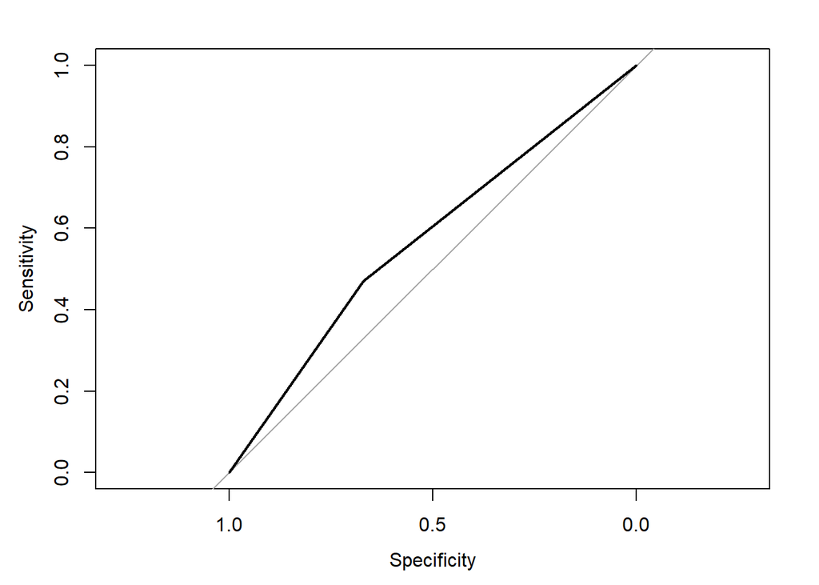

```r
plot(roc_object)
```

```r
# calculate area under curve
auc(roc_object)
```

```
## Area under the curve: 0.5707
```